# Asignment 1 - CNNs

# Data Exploration and Preparation

#### Authors:

- Izquierdo Álvarez, Mario
- Romero Romero, Martín

```python
import keras
import tensorflow as tf
import numpy as np
import math
from tensorflow.keras.preprocessing.image import img_to_array, load_img
import os
from tensorflow.keras.utils import image_dataset_from_directory
import shutil
import random
import matplotlib.pyplot as plt
from PIL import Image
```

## Splitting data into Train, Test and Validation sets

```python
# Path to the original dir with the images
dataset_path = 'data/original_data/train'
test_dataset_path = 'data/original_data/val'  # Notice that the original val data will be used as test

# Path to the new dir which will contain the splitted data
train_path = 'data/new_data/train'
val_path = 'data/new_data/validation'
test_path = 'data/new_data/test'

# Create folders for train, val, and test
os.makedirs(train_path, exist_ok=True)
os.makedirs(val_path, exist_ok=True)
os.makedirs(test_path, exist_ok=True)  # Ensure test_path directory exists

# Percentage of images to be used as training data (0.8 for 80%)
train_split = 0.8

# Split and copy train and validation images
for animal_folder in os.listdir(dataset_path):
    animal_images = os.listdir(os.path.join(dataset_path, animal_folder))
    random.shuffle(animal_images)

    # Compute the number of instances for each set
    num_train = int(len(animal_images) * train_split)
    train_images = animal_images[:num_train]
    val_images = animal_images[num_train:]

    # Copy train images to the train dir
    for image in train_images:
        src = os.path.join(dataset_path, animal_folder, image)
        dst = os.path.join(train_path, animal_folder, image)
        os.makedirs(os.path.join(train_path, animal_folder), exist_ok=True)
        shutil.copy(src, dst)

    # Copy validation images to the validation dir
    for image in val_images:
        src = os.path.join(dataset_path, animal_folder, image)
        dst = os.path.join(val_path, animal_folder, image)
        os.makedirs(os.path.join(val_path, animal_folder), exist_ok=True)
        shutil.copy(src, dst)

# Copy test images from original validation dataset to the test directory
for animal_folder in os.listdir(test_dataset_path):
    animal_images = os.listdir(os.path.join(test_dataset_path, animal_folder))
    os.makedirs(os.path.join(test_path, animal_folder), exist_ok=True)  # Ensure destination folder exists
    for image in animal_images:
        src = os.path.join(test_dataset_path, animal_folder, image)
        dst = os.path.join(test_path, animal_folder, image)
        shutil.copy(src, dst)
```

## Image size

Let's explore the different resolutions of the squared images within the original train folder (Which contains the train and validation data). We are goin to use this information to select a proper image resolution for the input of our CNN.

```python
dataset_path = 'data/original_data/train'

# Dicctionary to collect the squeared images sizes
square_image_resolutions = {}

# Walk through all the dirs and subdirs looking for images
for root, dirs, files in os.walk(dataset_path):
    for file in files:
        if file.lower().endswith(('.png', '.jpg', '.jpeg')):
            image_path = os.path.join(root, file)
            with Image.open(image_path) as img:
                width, height = img.size
                # Check if the image is squared
                if width == height:
                    # Increase the count for the resolution
                    if width in square_image_resolutions:
                        square_image_resolutions[width] += 1
                    else:
                        # Add the resolution to the dictionary
                        square_image_resolutions[width] = 1
```

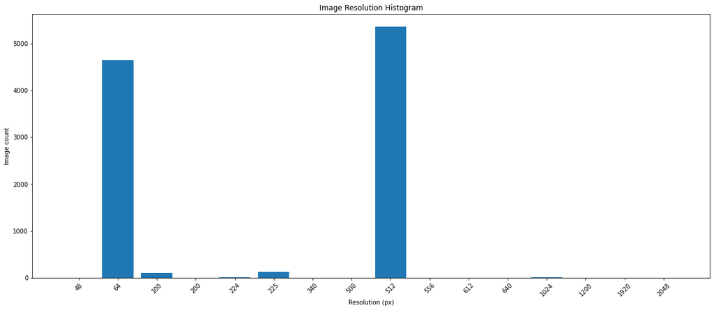

```python
resolutions = list(square_image_resolutions.keys())
counts = list(square_image_resolutions.values())

# Sorting resolutions and counts
sorted_indices = np.argsort(resolutions)
sorted_resolutions = np.array(resolutions)[sorted_indices]
sorted_counts = np.array(counts)[sorted_indices]

plt.figure(figsize=(20, 8))
plt.bar(sorted_resolutions.astype(str), sorted_counts, width=0.8)
plt.xlabel('Resolution (px)')
plt.ylabel('Image count')
plt.title('Image Resolution Histogram')
plt.xticks(rotation=45)
plt.show()
```

```python
image_size = (512, 512)
```

Selecting **512x512** pixels as the CNN input size is primarily informed by the prevalence of this resolution in the dataset, ensuring that the majority of images are processed in their **native resolution**, thereby preserving essential details and minimizing information loss. This choice strikes an optimal balance between capturing sufficient **image detail** for accurate pattern recognition and maintaining **computational efficiency**. Additionally, it simplifies the preprocessing pipeline by reducing the need for extensive resizing or adjustments, allowing the network to leverage high-resolution features effectively, thus optimizing performance based on **current dataset characteristics**.

## Creating the dataset objects

```python
batch_size = 32
```

```python
train_dataset = image_dataset_from_directory(
    'data/new_data/train',
    image_size = image_size,
    batch_size = batch_size)
test_dataset = image_dataset_from_directory(
    'data/new_data/test',
    image_size = image_size,
    batch_size=batch_size)
val_dataset = image_dataset_from_directory(
    'data/new_data/validation',
    image_size = image_size,
    batch_size=batch_size)
```

```
Found 10778 files belonging to 5 classes.
Found 1497 files belonging to 5 classes.
Found 2696 files belonging to 5 classes.
```

## Exploration of the images

### Ploting some images

```python
class_names = train_dataset.class_names
class_names
```

```
['cat', 'dog', 'elephant', 'horse', 'lion']
```

[figure not shown]

```python
n_images = 10
for images, labels in train_dataset.take(1):
    plt.figure(figsize=(25,10))
    for i in range(n_images):
        plt.subplot(n_images//5, 5, i+1)
        plt.imshow(images[i].numpy().astype("uint8"))
        plt.title(f"Label: {class_names[labels[i]]}")
        plt.axis("off")

    plt.show()
```

## Class distribution

Let's plot the distribution for the clases within the different datasets to check that all datasets are **representative** for **all classes**

```python
def plot_class_distribution(datasets, titles):
    # Ensure the number of datasets and titles match and there are exactly three of each
    assert len(datasets) == len(titles) == 3, "There must be exactly 3 datasets and 3 titles."

    plt.figure(figsize=(18, 6))  # Adjust the figure size to accommodate three subplots

    # Iterate through each dataset and corresponding title
    for i, (dataset, title) in enumerate(zip(datasets, titles), start=1):
        plt.subplot(1, 3, i)  # Create a subplot in the row

        class_names = dataset.class_names
        labels = np.concatenate([y for x, y in dataset], axis=0)
        unique, counts = np.unique(labels, return_counts=True)
        labels_names = [class_names[label] for label in unique]

        plt.bar(unique, counts)
        plt.title(title)
        plt.xlabel('Classes')
        plt.ylabel('Image Count')
        plt.xticks(unique, labels_names, rotation=45, ha="right")  # Adjust labels to be class names

    plt.tight_layout()  # Automatically adjust subplot parameters to give specified padding
    plt.show()
```

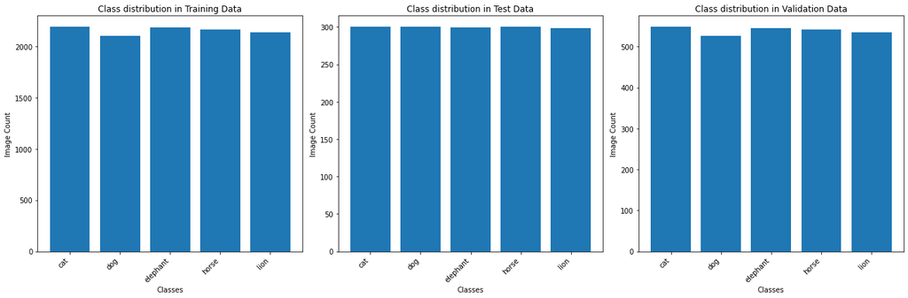

```python
datasets = [train_dataset, test_dataset, val_dataset]
titles = ['Class distribution in Training Data', 'Class distribution in Test Data', 'Class distribution in Validation Data']
plot_class_distribution(datasets, titles)
```